# Факторный и дискриминантный анализ.

## Построение деревьев классификации

```r
library(rpart)
# Модель с информационным выигрышем (Используем критерий "entropy")
tree_gain <- rpart(factor(train_data$end) ~ ., data = train_data, method = "class", parms = list(split = "information"))

# Стандартная модель (Используем критерий "gini")
tree_standard <- rpart(factor(train_data$end) ~ ., data = train_data, method = "class", parms = list(split = "gini"))

# Предсказания для модели на основе информационного выигрыша
y_pred_gain <- predict(tree_gain, test_data, type = "class")

# Предсказания для стандартной модели
y_pred_standard <- predict(tree_standard, test_data, type = "class")

# Расчет точности для модели с информационным выигрышем
accuracy_gain <- confusionMatrix(y_pred_gain, factor(test_data$end))$overall['Accuracy']

# Расчет точности для стандартной модели
accuracy_standard <- confusionMatrix(y_pred_standard, factor(test_data$end))$overall['Accuracy']

# Вывод результатов
cat(sprintf("Точность модели с информационным выигрышем: %.3f\n", accuracy_gain))
```

```
## Точность модели с информационным выигрышем: 0.566
```

```r
cat(sprintf("Точность стандартной модели: %.3f\n", accuracy_standard))
```

```
## Точность стандартной модели: 0.602
```

```r
library(gridExtra)

plot_confusion_matrix <- function(y_true, y_pred, title) {
  # Преобразуем y_pred и y_true в факторы для работы confusionMatrix
  conf_matrix <- confusionMatrix(as.factor(y_pred), as.factor(y_true))
  print(conf_matrix)

  # Преобразуем таблицу матрицы ошибок в dataframe для ggplot
  conf_matrix_df <- as.data.frame(conf_matrix$table)
  names(conf_matrix_df) <- c("Reference", "Prediction", "Freq")

  # Построение матрицы ошибок с помощью ggplot
  ggplot(conf_matrix_df, aes(x = Reference, y = Prediction, fill = Freq)) +
    geom_tile(colour = "white") +  # Здесь теперь корректно используется x и y
    geom_text(aes(label = Freq), vjust = 1.5, color = "black") +
    scale_fill_gradient(low = "white", high = "steelblue") +
    labs(title = title, x = "Предсказанное", y = "Действительное") +
    theme_minimal() +
    theme(axis.text.x = element_text(angle = 45, hjust = 1),
          plot.title = element_text(hjust = 0.5))
}

# Создание графиков для каждой модели
p1 <- plot_confusion_matrix(test_data$end, y_pred_gain, "Модель дерево с информационным выигрышем")
```

```
## Confusion Matrix and Statistics
##
##           Reference
## Prediction  0  1
##          0 45 23
##          1 13  2
##
##                Accuracy : 0.5663
##                  95% CI : (0.4529, 0.6747)
##     No Information Rate : 0.6988
##     P-Value [Acc > NIR] : 0.9962
##
##                   Kappa : -0.1626
##
##  Mcnemar's Test P-Value : 0.1336
##
##             Sensitivity : 0.7759
##             Specificity : 0.0800
##          Pos Pred Value : 0.6618
##          Neg Pred Value : 0.1333
##              Prevalence : 0.6988
##          Detection Rate : 0.5422
##    Detection Prevalence : 0.8193
##       Balanced Accuracy : 0.4279
##
##        'Positive' Class : 0
##
```

```r
p2 <- plot_confusion_matrix(test_data$end, y_pred_standard, "Модель дерево стандартное")
```

```
## Confusion Matrix and Statistics
##
##           Reference
## Prediction  0  1
##          0 43 18
##          1 15  7
##
##                Accuracy : 0.6024
##                  95% CI : (0.489, 0.7083)
##     No Information Rate : 0.6988
##     P-Value [Acc > NIR] : 0.9769
##
##                   Kappa : 0.0221
##
##  Mcnemar's Test P-Value : 0.7277
##
##             Sensitivity : 0.7414
##             Specificity : 0.2800
##          Pos Pred Value : 0.7049
##          Neg Pred Value : 0.3182
##              Prevalence : 0.6988
##          Detection Rate : 0.5181
##    Detection Prevalence : 0.7349
##       Balanced Accuracy : 0.5107
##
##        'Positive' Class : 0
##
```

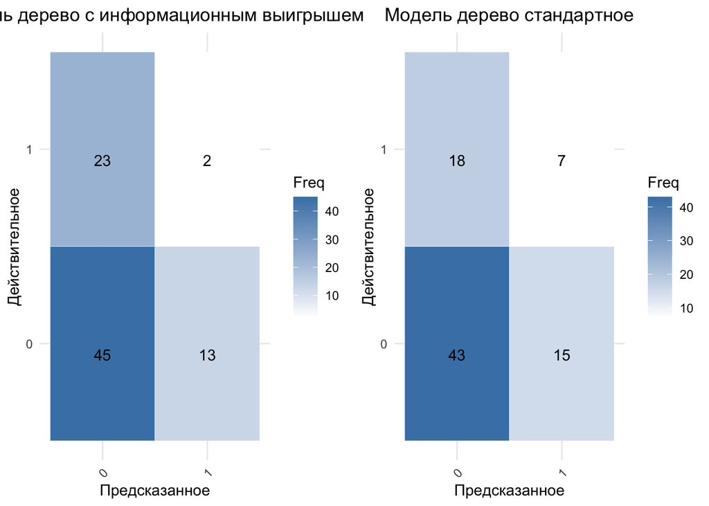

```r
# Объединение графиков в один ряд
grid.arrange(p1, p2, ncol = 2)
```

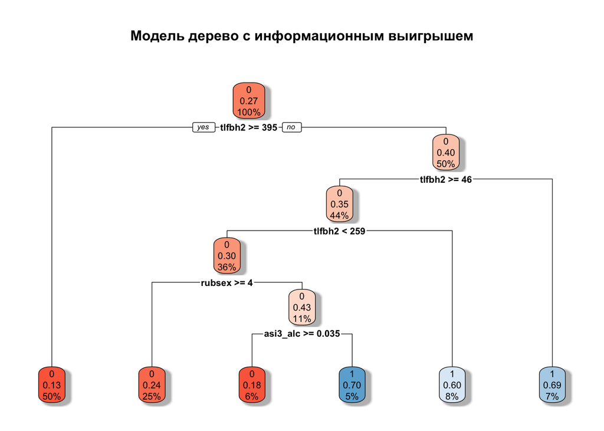

```r
library(rpart.plot)
# Визуализация дерева
rpart.plot(tree_gain, main="Модель дерево с информационным выигрышем", box.palette="RdBu", shadow.col="gray", border.col="black")
```

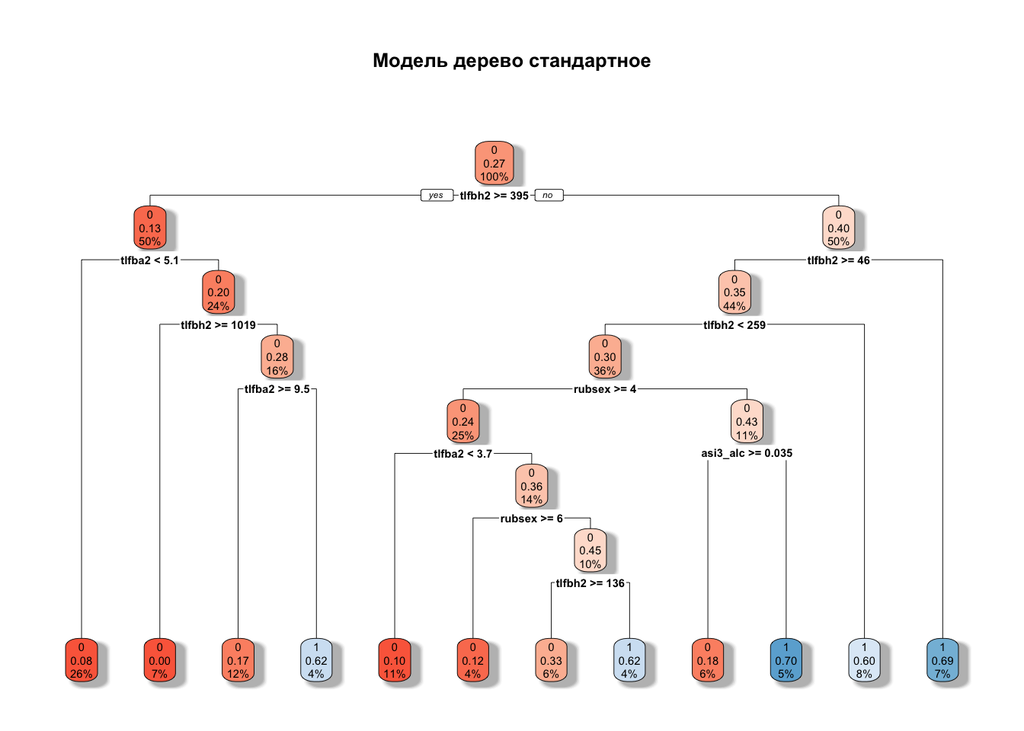

```r
# Визуализация дерева
rpart.plot(tree_standard, main="Модель дерево стандартное", box.palette="RdBu", shadow.col="gray", border.col="black")
```

Из результатов видно, что точность стандартной модели дерева решений, использующей индекс Джини (`0.602`), выше, чем модели, использующей критерий информационного выигрыша (`0.566`).

Исходя из вывода матрицы ошибок и статистики, видно, что модель дерева решений с критерием информационного выигрыша показывает довольно низкую общую точность (Accuracy) 56.63% и негативное значение Каппа (Kappa), что указывает на слабое согласие между предсказаниями и фактическими значениями.

Результаты для стандартной модели дерева решений, использующей критерий Джини, также показывают умеренную точность (Accuracy) 60.24%.